# Pre-processing

Julia Schwarz

28/10/2021

## Updates compared to the previous version (to be discussed):

- c135 is re-introuded and re-evaluated, as there are worse dataset than that.
- New variables introduced: age, sex, trial, block
- Reaction time lower than 0 ms is not excluded, since this time we have much more data below 0ms. However, for log transformation, adding a small value to it and make all data positive might give better distribution.
- We also inspect annotation notes.
- Transfomation not decided yet.

## Data File

Raw data file with all 33 adults + 31 children, no data removed except empty responses. **7870** observations.

From first batch of files: 17 adults and 17 children.

From second batch of files: 16 adults and 14 children.

```
## [1] "Total data:  7870"
```

| group | n |
| --- | --- |
| a | 33 |
| c | 31 |

## Variable Prep

New variables here: *TRIAL*, *BLOCK*, *AGE*, *SEX*

## Exclude training trials

8 training trials per participant excluded. Remaining data = **7393**.

```r
data <- data %>%
  filter(display != "Practice") # the same as below
data <- subset(data, data$ITEM != '101L')
data <- subset(data, data$ITEM != '48L')
data <- subset(data, data$ITEM != '44L')
data <- subset(data, data$ITEM != '45H')
data <- subset(data, data$ITEM != '13H')
data <- subset(data, data$ITEM != '102L')
data <- subset(data, data$ITEM != '55H')
data <- subset(data, data$ITEM != '52H')
print(paste("Remaining data: ", nrow(data)))
```

```
## [1] "Remaining data:  7393"
```

## Participant screening

Based on the examination of recordings, we excluded participants reporting low commitment to the task (irrelevant speaking, background noise), any major misunderstandings of the instructions, or significant technical problems (e.g. with the experiment display). Relative information are noted down in the Google sheet ‘Missing Trials or Answers’.

Besieds, based on the post-experiment questionnaire, we excluded participants who do not match our recruitment criterial despite pre-screening (e.g. dyslexia, cf. Data collection procedures).

**Exclude a180 - dyalexia; 210725_a113 - effot doubtful; 210719_a59 - poor recording quality.**

```
## [1] "Remaining data:  7033"
```

The rest filtering are based on data patterns.

### Based on the total number of trials

Remaining data: **6961**

Now we have 30 adults and 30 children.

```r
data %>%
  group_by(GROUP, parid) %>%
  summarise(count = n()) %>%
  filter(count<100)
```

| GROUP | parid | count |
| --- | --- | --- |
| c | 210719_c43 | 75 |
| c | 210719_c45 | 76 |
| c | 210725_c96 | 72 |
| c | 210725_c98 | 68 |

```r
data <- subset(data, data$SUBJECT != '210725_c96')

print(paste("Remaining data: ", nrow(data)))
```

```
## [1] "Remaining data:  6961"
```

```r
# Check if adult & children match
data[!duplicated(data$parid),] %>%
  group_by(GROUP) %>%
  summarise(n = n())
```

| GROUP | n |
| --- | --- |
| a | 30 |
| c | 30 |

```r
# Check if sex match
data[!duplicated(data$parid),] %>%
  group_by(GROUP,SEX) %>%
  summarise(n = n())
```

| GROUP | SEX | n |
| --- | --- | --- |
| a | Female | 20 |
| a | Male | 10 |
| c | Female | 17 |
| c | Male | 13 |

### Based on accuracy

We will exclude participants with an error rate above 20% .

Participants with error rate above 20%: NONE Participants with error rate above 10%: c29, c135

**c29 and c135 needs inspection.**

**No exclusion**

```r
data %>%
  group_by(parid) %>%
  summarise(errorrate = (1-sum(accuracy)/n())*100) %>%
  filter(errorrate > 10)
```

| parid | errorrate |
| --- | --- |
| 210719_c29 | 10.25641 |
| 210725_c135 | 12.60504 |

## Items and trials (exclude items w high error rate)

Target words with an error rate of 40% or higher (cf. Crepaldi et al. 2016) will be removed from the analysis.

Items w 40% error rate or higher: NONE Items w higher than 20% error rate: 64L: 21.4% 21L: 20.6% 86L: 20.6%

**No targets removed based on error rate.**

**We excluded three ambiguous target words: knob, meal, net.**

Remaining trials: **6785**

```r
data %>%
  group_by(ITEM) %>%
  summarise(errorrate = 100*(1-sum(accuracy)/n())) %>%
  filter(errorrate > 20)
```

| ITEM | errorrate |
| --- | --- |
| 21L | 20.58824 |
| 64L | 21.42857 |
| 86L | 20.58824 |

```r
data <- subset(data, data$correctans != 'knob')
data <- subset(data, data$correctans != 'meal')
data <- subset(data, data$correctans != 'net')

print(paste("Remaining trials: ", nrow(data)))
```

```
## [1] "Remaining trials:  6785"
```

### Exclude trials with notes of ‘discard’

In the correct responses (ACC ==1), we delete the ones with ‘discard’ marking (7 removed), because it’s not possible to mark the speech onset accurately, but we keep the ones with ‘unsure’ marking (including participants sounding unsure; and coder unsure because of overlapping sound.)

Remaining data = **6778**.

```r
# The negation of (data$ACC = 1 & grepl('discard',note))
data <- subset(data, data$ACC !=1 | !grepl('discard',note))
print(paste("Remaining trials: ", nrow(data)))
```

```
## [1] "Remaining trials:  6778"
```

```r
# store the number at the current stage
x = nrow(data)
```

### Exclude incorrect trials

Incorrect and problematic trials were removed (N=272, 4.01%). We will analyse wrong trials separately.

Remaining trials: **6506**

```r
error <- subset(data, data$ACC!=1)
write.csv(error,"220107_unfiltered_error.csv")
```

```r
data <- subset(data, data$ACC != 0)
print(paste("Wrong trials: ", x-nrow(data), "(error rate: ", 100*(x-nrow(data))/x, ")"))
```

```
## [1] "Wrong trials:  272 (error rate:  4.01298318087932 )"
```

```r
print(paste("Remaining trials: ", nrow(data)))
```

```
## [1] "Remaining trials:  6506"
```

## Inspect data and remove unnatural responses

```r
range(data$RT)
```

```
## [1]  -410.56 16809.98
```

```r
data$RTcut = cut(data$RT,breaks = c(-500,-50,0,1000,3000,20000))
table(data$RTcut)
```

```
##
##    (-500,-50]       (-50,0]     (0,1e+03] (1e+03,3e+03] (3e+03,2e+04]
##            55            57          5462           903            29
```

After this cleaning process, reaction times will be inspected with histograms, with boxplots, and by Participant with qqplot. Data remaining: **6477**.

```
## [1] "Remaining trials:  6477"
```

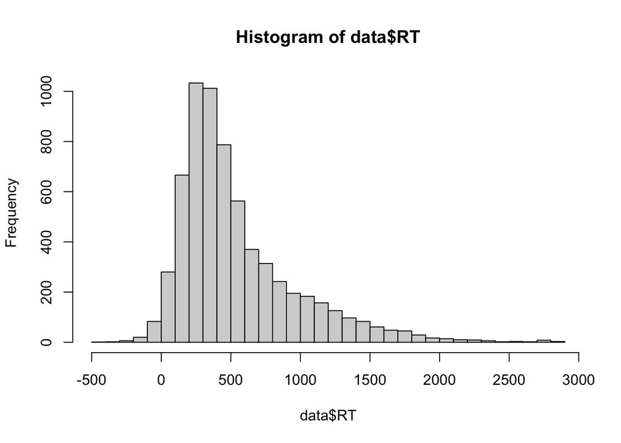

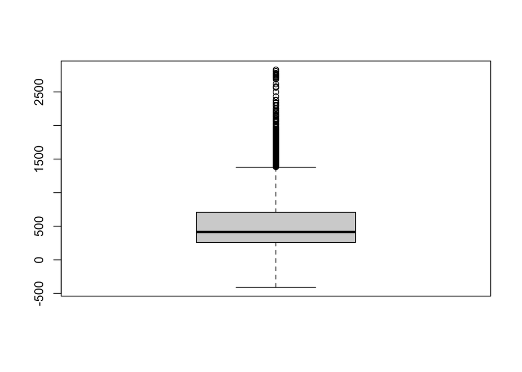

```
## [1] 1.56224
```

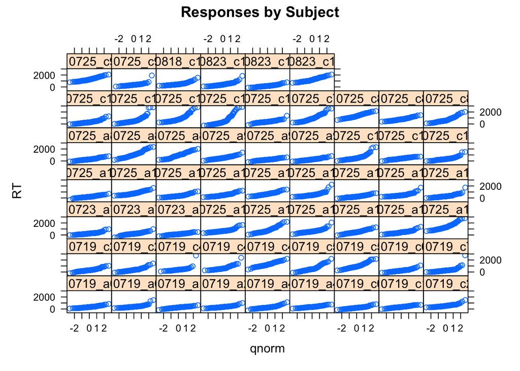

### Distraction and Difficulty (commitment to the experiment)

Difficulty.y >3: **210723_a78** (Difficulty 5, Distraction 3)

Distraction >3: **210725_c133** (Difficulty 2, Disctraction 4)

**Nothing excluded**

```r
# remove duplicated, only consider one line per participant
# CI interval
diffi_distr <- data[!duplicated(data$parid),] %>%
  summarise(difficulty.mean = mean(Difficulty.y),
            difficulty.sd = sd(Difficulty.y),
            n = n(),
            diffculty.min = min(Difficulty.y),
            diffculty.max = max(Difficulty.y),
            distraction.mean = mean(Distraction),
            distraction.sd = sd(Distraction),
            distraction.min = min(Distraction),
            distraction.max = max(Distraction),
            )%>%
  mutate(difficulty.se = difficulty.sd/sqrt(n),
         distraction.se = distraction.sd/sqrt(n),
         difficulty.lower.ci = difficulty.mean - qt(1-(0.05/2), n -1) * difficulty.se,
         difficulty.upper.ci = difficulty.mean + qt(1-(0.05/2), n -1) * difficulty.se,
         distraction.lower.ci = distraction.mean - qt(1-(0.05/2), n -1) * distraction.se,
         distraction.upper.ci = distraction.mean + qt(1-(0.05/2), n -1) * distraction.se
  ) %>%
  select(difficulty.mean, difficulty.sd, difficulty.lower.ci, difficulty.upper.ci, distraction.mean, distraction.sd, distraction.lower.ci, distraction.upper.ci)
diffi_distr
```

| difficulty.mean | difficulty.sd | difficulty.lower.ci | difficulty.upper.ci | distraction.mean | distraction.sd | distraction.lower.ci | distraction.upper.ci |
| --- | --- | --- | --- | --- | --- | --- | --- |
| 1.8 | 0.7318423 | 1.610945 | 1.989055 | 1.716667 | 0.7611692 | 1.520036 | 1.913298 |

```r
# difficultymean <- groupwiseMean(Difficulty.y,
#                            data   = Qpart,
#                            conf   = 0.95,
#                            digits = 3)
```

## Transform reaction times and remove outliers

The data were found to be positively skewed. Therefore we tested common transformations (actually only tested log so far) and chose the one with the best fit/but found no satisfactory improvement. Outliers three standard deviations from the mean per participant were removed.

```
## [1] 1.56224
```

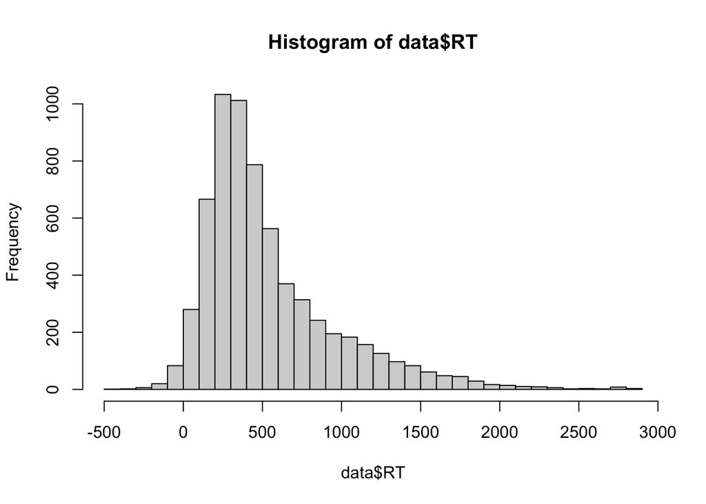

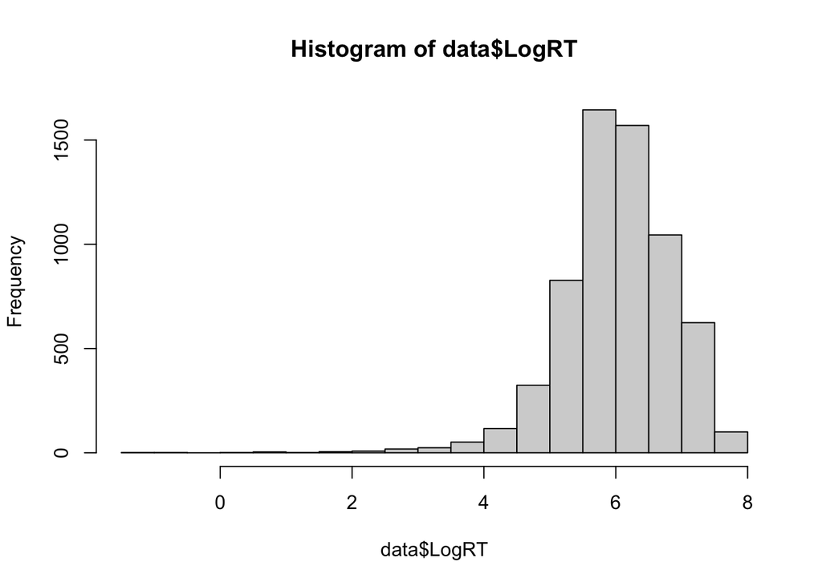

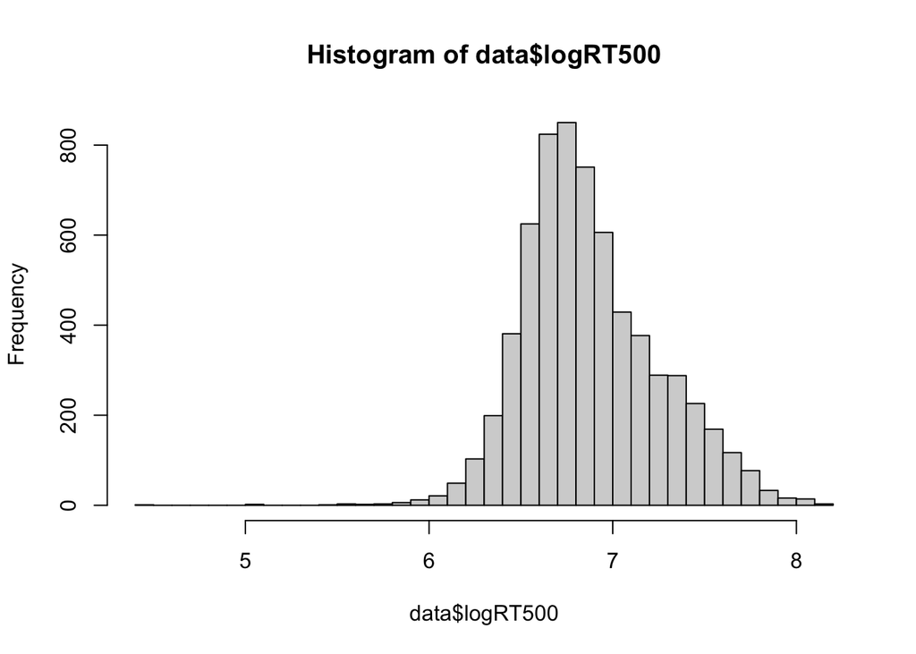

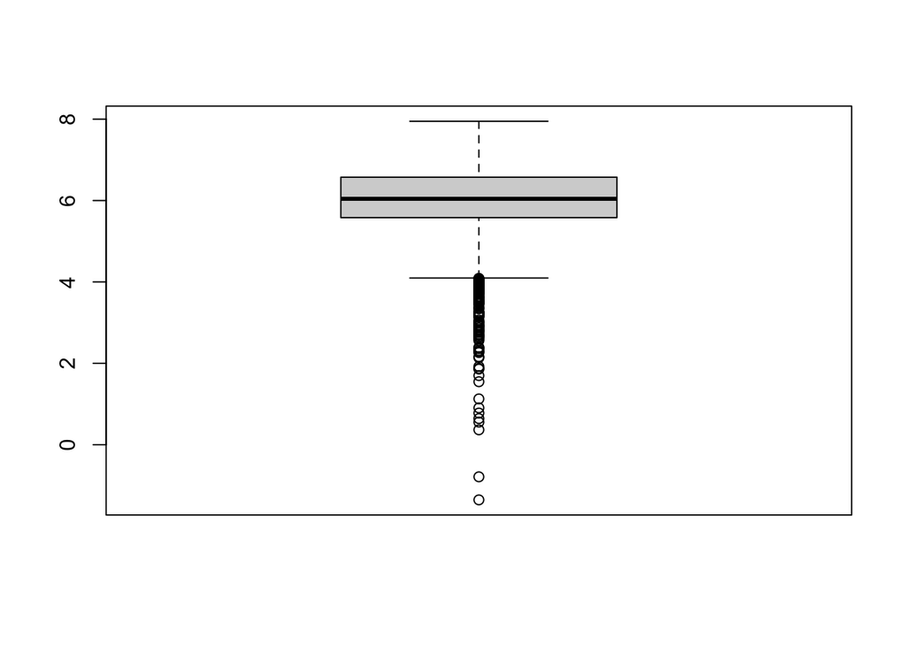

```
## [1] -1.056606
```

```
## [1] 0.3981032
```

```
## [1] 1.427507
```

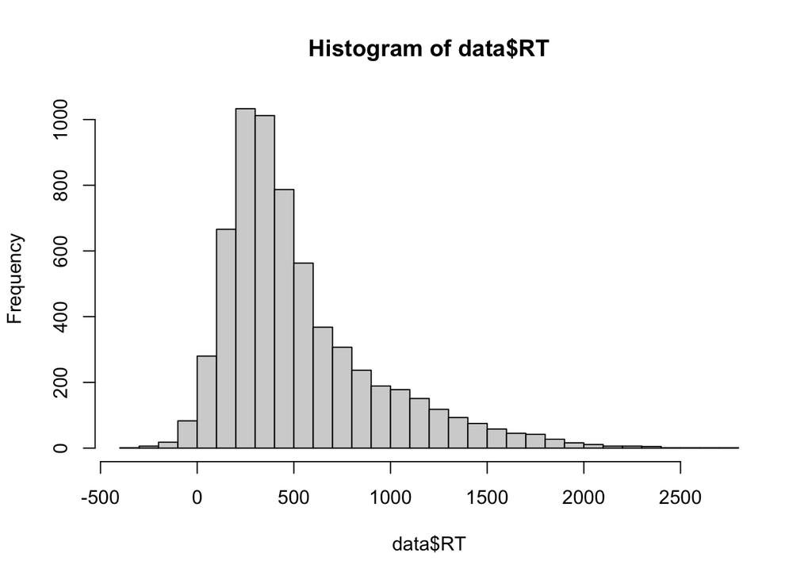

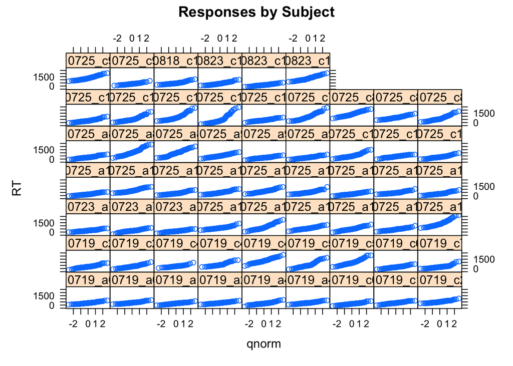

## Save cleaned data sheet

```r
write.table(data, "220107_full_data_cleaned.txt", sep="\t", row.names=FALSE)
```